# index.Rmd

woojin, matt, evan, celine

5/16/2021

## Introduction

Our group is interested in this domain because sleep is a topic that is highly relevant for college students and emerging adults entering the workforce. Many people maintain busy lives but often forget to balance it with proper sleep and behaviors that benefit sleep health.

One of the data in our datasets was collected by the American Time Use Survey from the Bureau of Labor Statistics by surveying a random sample of Americans ages 15 years and older. The participants were grouped by age group and sex. This data helps us analyze the differences in the amount of sleep Americans of different ages and sex get. With a focus on age and sex, we can better analyze the impact these variables have on the amount of sleep people get on average and analyze the general trend of the average sleep hours of people.

The data from Michael Lomuscio who teaches data science at an international boarding school in the U.S. was also collected to analyze the factors that impact the student’s sleep quality. This data represents his student’s opinions on if they are receiving adequate sleep, hours a student slept, if their phone is within their reach while in bed, phone usage 30 minutes before they sleep, results from a Likert type scale based on how tired they are throughout the day, and if they eat breakfast or not.

## Summary Information

From the data by Michael Lomuscio who collected the data from students in international boarding school, our team founded that on average, students think that they get enough sleep when they slept 7.4 hours. The average sleep hours for the phone-use group(the students who use the phone within 30 minutes of falling asleep) was 6.759 hours while the non-phone-use group(the students who do not use the phone before falling asleep) had 6.211 hours on average. We could observe that both groups do not reach the average ideal sleeping hours(7.4) that students felt enough. With those two data points, we could also observe that the phone-use group slept more than the non-phone-use group. However, only 34.5% of the phone-use group said that they are getting enough sleep while 35% of the non-phone-use group agreed with getting enough sleep. Even though the non-phone-use group slept less, they had a higher percentage of students who agreed with getting enough sleep. From these analyses, we got an insight that rather than the sleep hours, phone usage before sleeping might impact the sleep quality of the individuals.

Not only the phone usage but eating breakfast also impacted the students’ sleeping. The average sleep hour for the breakfast group(students who eat breakfast) was 6.918 hours while the non-breakfast group(students who do not eat breakfast) had 6.268 hours. 39.7% of the breakfast group agreed that they are having enough sleep while only 26.8% of the non-breakfast group agreed. The breakfast group seemed to have more percentage because they slept more than the non-breakfast group. However, the ratio of avg sleep hours between the two groups was 1:1.1 (non-breakfast:breakfast), and the ratio of percent of students agreeing with getting enough sleep was 1:1.48 (non-breakfast:breakfast). If the breakfast group was having a higher percentage of students agreeing with having enough sleep because they slept more, then those ratios should be the same. Since the ratio of students’ enough rate between two groups is higher than the ratio of avg sleep hours, we can conclude that even though we considered the difference between their average sleep hours, still the breakfast group tends to have more students with enough sleep. The analysis from this dataset shows that rather than the hours of sleep, the students’ behaviors(phone usage and breakfast) are affecting the sleep quality of individuals.

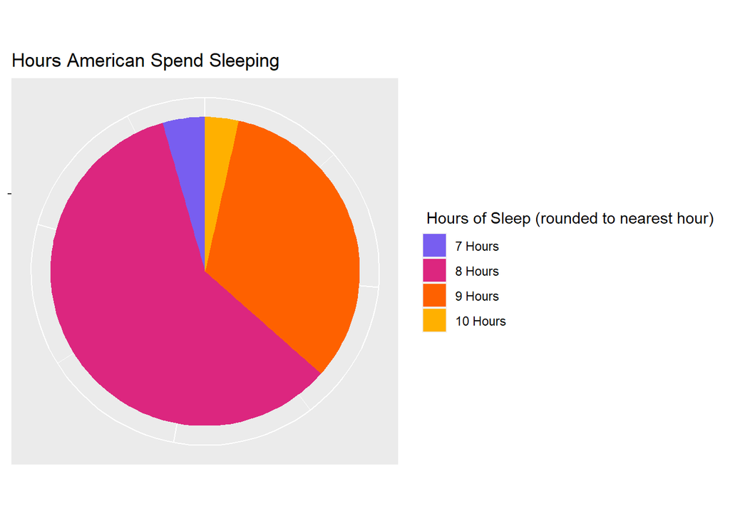